# Kohnen-Quervergleich: B50 (head03) gegen B40 (head04)

Standortunterschied im Tiefenprofil — plus Kalibrier- und Driftkontrolle

Author

Thom Laepple

Published

September 24, 2026

Beide Kohnen-Systeme messen dieselbe Größe an zwei Bohrlöchern, mit **völlig getrennten Kalibrierketten**:

|  | head03 / **B50** | head04 / **B40** |
| --- | --- | --- |
| Kette | C25.4.A, 60 m, in Luft (11 Knoten, 5–62 m) | Bohrlochkette, 1–201 m (20 Knoten) |
| Kalibrierung | Calibration Registry, Batch `kohnen2526`, cal_id `2025-11_vorKohnen` | Labor-S4 2023 (Variante „Both”: Fluke + Klimakammer) |
| Quelle | `data/head03_depths.csv` + Registry | `data/head04_calibration.csv` |

In die Differenz gehen zwei Dinge ein: ein **realer Standortunterschied** zwischen B50 und B40 und der **Absolutfehler beider Kalibrierungen**. Die beiden lassen sich trennen, weil es eine unabhängige Messung gibt:

> **Feldbefund:** Der Versatz zwischen den Standorten wurde bereits vor Ort mit der **Winde** festgestellt — mit **denselben Sensoren** in beiden Bohrlöchern. Bei identischen Sensoren kürzt sich die Kalibrierung exakt heraus; der dort gemessene Unterschied ist also **real und standortbedingt**.

Damit ist die Rollenverteilung klar: Die Differenz unten misst primär den **Standortunterschied**; sie begrenzt zugleich den Kalibrierfehler nach oben, denn beide Beiträge zusammen sind so klein wie unten zu sehen. Und die **Zeitreihe** der Differenz ist der reine Drifttest — ein Standortversatz ist zeitlich stabil, eine driftende Kalibrierung nicht.

```r
library(readr); library(dplyr); library(tidyr); library(ggplot2)
library(lubridate); library(patchwork)

d3   <- read_csv("./data/decoded_head03_231709_combined.csv", show_col_types = FALSE) |>
  mutate(time_utc = as_datetime(time_utc))
d4   <- read_csv("./data/decoded_head04_231710_combined.csv", show_col_types = FALSE) |>
  mutate(time_utc = as_datetime(time_utc))
dep3 <- read_csv("./data/head03_depths.csv", show_col_types = FALSE)
cal4 <- read_csv("./data/head04_calibration.csv", show_col_types = FALSE) |>
  distinct(node, depth_m)

# Gemeinsames Fenster: letzte 3 Wochen, in denen BEIDE Systeme gesendet haben.
t_end <- min(max(d3$time_utc), max(d4$time_utc))
win   <- c(t_end - 21*86400, t_end)

prof <- function(d, nodes) sapply(nodes, function(i) {
  a <- d[[sprintf("n%d.ntc1_temp_C", i)]]; b <- d[[sprintf("n%d.ntc2_temp_C", i)]]
  x <- rowMeans(cbind(a, b), na.rm = TRUE)
  mean(x[d$time_utc >= win[1] & d$time_utc <= win[2]], na.rm = TRUE) })

n3 <- dep3$node[dep3$chain == "C25.4.A (60 m, Luft)"]
p3 <- tibble(depth = dep3$depth_m[n3], T = prof(d3, n3), Kopf = "head03 / B50")
n4 <- cal4$node[cal4$node <= 20]
p4 <- tibble(depth = cal4$depth_m[cal4$node <= 20], T = prof(d4, n4), Kopf = "head04 / B40")

dif <- p3 |> mutate(T4 = approx(p4$depth, p4$T, xout = depth, rule = 2)$y,
                    diff_mK = 1000*(T - T4))
deep <- dif |> filter(depth >= 13)
```

**Auswertefenster:** 01.07.2026 – 22.07.2026 (die letzten drei Wochen, in denen beide Systeme gesendet haben).

## Profile und Differenz

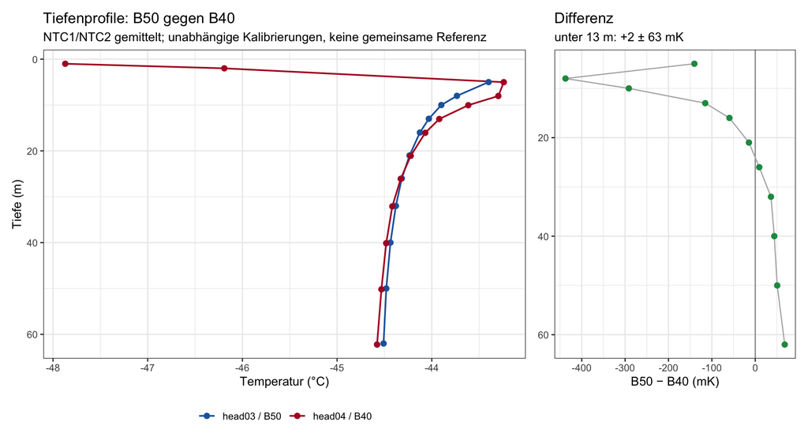

```r
both <- bind_rows(p3, p4) |> filter(depth <= 70)
p_prof <- ggplot(both, aes(T, depth, colour = Kopf)) +
  geom_path(linewidth = 0.7) + geom_point(size = 2) +
  scale_y_reverse("Tiefe (m)") + scale_x_continuous("Temperatur (°C)") +
  scale_colour_manual(NULL, values = c("head03 / B50" = "#2166ac",
                                       "head04 / B40" = "#b2182b")) +
  labs(title = "Tiefenprofile: B50 gegen B40",
       subtitle = "NTC1/NTC2 gemittelt; unabhängige Kalibrierungen, keine gemeinsame Referenz") +
  theme_bw(11) + theme(legend.position = "bottom")

p_diff <- ggplot(dif, aes(diff_mK, depth)) +
  geom_vline(xintercept = 0, colour = "grey60") +
  geom_path(colour = "grey70") + geom_point(size = 2, colour = "#1a9850") +
  scale_y_reverse(NULL) + scale_x_continuous("B50 − B40 (mK)") +
  labs(title = "Differenz",
       subtitle = sprintf("unter 13 m: %+.0f ± %.0f mK", mean(deep$diff_mK), sd(deep$diff_mK))) +
  theme_bw(11)

p_prof + p_diff + plot_layout(widths = c(2, 1))
```

```r
knitr::kable(dif |> transmute(`Tiefe (m)` = depth,
                              `B50 (°C)` = round(T, 3), `B40 (°C)` = round(T4, 3),
                              `Differenz (mK)` = round(diff_mK, 0)),
             caption = "Knotenweiser Vergleich (die B40-Kette hat fast identische Nominaltiefen, die Interpolation ist daher praktisch exakt).")
```

Knotenweiser Vergleich (die B40-Kette hat fast identische Nominaltiefen, die Interpolation ist daher praktisch exakt).

| Tiefe (m) | B50 (°C) | B40 (°C) | Differenz (mK) |
| --- | --- | --- | --- |
| 5 | -43.400 | -43.259 | -140 |
| 8 | -43.734 | -43.297 | -437 |
| 10 | -43.899 | -43.608 | -291 |
| 13 | -44.031 | -43.916 | -115 |
| 16 | -44.126 | -44.066 | -60 |
| 21 | -44.235 | -44.220 | -15 |
| 26 | -44.317 | -44.326 | 9 |
| 32 | -44.379 | -44.415 | 36 |
| 40 | -44.436 | -44.480 | 44 |
| 50 | -44.480 | -44.531 | 51 |
| 62 | -44.509 | -44.577 | 68 |

## Befund

```r
g3 <- deep$T[nrow(deep)]  - deep$T[1]
g4 <- deep$T4[nrow(deep)] - deep$T4[1]
cat(sprintf("- **Tiefer Bereich (13–62 m): %+.0f ± %.0f mK** (Spannweite %.0f mK). Standortunterschied und Kalibrierfehler zusammen bleiben damit im Bereich weniger zehn mK — für zwei Standorte, zwei Geräte und zwei unabhängig entstandene Kalibrierungen ein enger Rahmen.\n",
            mean(deep$diff_mK), sd(deep$diff_mK), diff(range(deep$diff_mK))))
```

[output not shown]

```r
cat(sprintf("- **Oben (5–10 m) läuft die Differenz auf bis zu %.0f mK auf.** Das ist kein Kalibrierfehler, sondern die saisonale Welle: Amplitude und Phase hängen von lokaler Akkumulation und Schneedichte ab, und bei ~8 m ist der Gradient der Welle am steilsten.\n",
            max(abs(dif$diff_mK[dif$depth < 13]))))
```

- **Oben (5–10 m) läuft die Differenz auf bis zu 437 mK auf.** Das ist kein Kalibrierfehler, sondern die saisonale Welle: Amplitude und Phase hängen von lokaler Akkumulation und Schneedichte ab, und bei ~8 m ist der Gradient der Welle am steilsten.

```r
cat(sprintf("- **Tiefengradient 13 → 62 m: B50 %+.3f K, B40 %+.3f K** (Differenz %.3f K). Der Gradient trägt das Paläosignal; %s\n",
            g3, g4, abs(g3-g4),
            if (abs(g3-g4) > 0.1)
              "nach dem Winden-Befund (dieselben Sensoren in beiden Bohrlöchern) ist das ein **realer Standortunterschied**, kein Kalibriereffekt — die Bohrlöcher tragen unterschiedliche Oberflächentemperatur- bzw. Akkumulationsgeschichten. Für eine gemeinsame Paläo-Inversion heißt das: getrennt invertieren und die Standortdifferenz als Signal behandeln, nicht als Fehler."
            else "beide Systeme sehen dieselbe Klimageschichte."))
```

- **Tiefengradient 13 → 62 m: B50 -0.478 K, B40 -0.661 K** (Differenz 0.183 K). Der Gradient trägt das Paläosignal; nach dem Winden-Befund (dieselben Sensoren in beiden Bohrlöchern) ist das ein **realer Standortunterschied**, kein Kalibriereffekt — die Bohrlöcher tragen unterschiedliche Oberflächentemperatur- bzw. Akkumulationsgeschichten. Für eine gemeinsame Paläo-Inversion heißt das: getrennt invertieren und die Standortdifferenz als Signal behandeln, nicht als Fehler.

## Zeitreihe der Differenz

Ein Standortversatz ist zeitlich konstant, eine driftende Kalibrierung nicht — die Zeitreihe trennt beides. Gezeigt ist der tiefste gemeinsame Knoten, wo das Saisonsignal vollständig weg ist.

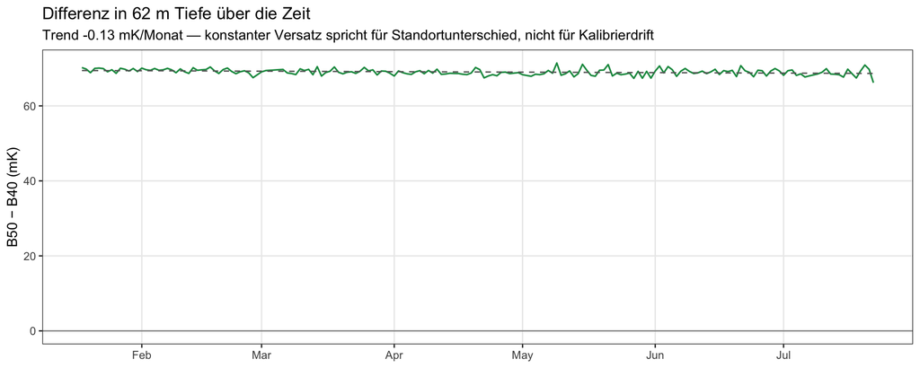

```r
i3 <- dep3$node[dep3$chain == "C25.4.A (60 m, Luft)"] |> tail(1)
i4 <- cal4$node[which.min(abs(cal4$depth_m - dep3$depth_m[i3]))]
ts <- inner_join(
  d3 |> transmute(day = as.Date(time_utc),
                  t3 = rowMeans(cbind(.data[[sprintf("n%d.ntc1_temp_C", i3)]],
                                      .data[[sprintf("n%d.ntc2_temp_C", i3)]]), na.rm = TRUE)) |>
    group_by(day) |> summarise(t3 = mean(t3, na.rm = TRUE), .groups = "drop"),
  d4 |> transmute(day = as.Date(time_utc),
                  t4 = rowMeans(cbind(.data[[sprintf("n%d.ntc1_temp_C", i4)]],
                                      .data[[sprintf("n%d.ntc2_temp_C", i4)]]), na.rm = TRUE)) |>
    group_by(day) |> summarise(t4 = mean(t4, na.rm = TRUE), .groups = "drop"),
  by = "day") |> mutate(diff_mK = 1000*(t3 - t4))

ggplot(ts, aes(day, diff_mK)) +
  geom_hline(yintercept = 0, colour = "grey60") +
  geom_line(colour = "#1a9850", linewidth = 0.6) +
  geom_smooth(method = "lm", se = FALSE, colour = "grey40", linetype = "dashed", linewidth = 0.5) +
  scale_x_date(NULL) + scale_y_continuous("B50 − B40 (mK)") +
  labs(title = sprintf("Differenz in %.0f m Tiefe über die Zeit", dep3$depth_m[i3]),
       subtitle = sprintf("Trend %+.2f mK/Monat — konstanter Versatz spricht für Standortunterschied, nicht für Kalibrierdrift",
                          coef(lm(diff_mK ~ as.numeric(day), data = ts))[2]*30)) +
  theme_bw(11) + theme(panel.grid.minor = element_blank())
```